# Data Visualization With ggplot2

Jan 23, 2018

## Outline

We will spend next couple lectures studying R. I'll closely follow a few great books by Hadley Wickham.

- Data wrangling (import, visualization, transformation, tidy).  
  [R for Data Science](http://r4ds.had.co.nz) by Garrett Grolemund and Hadley Wickham.
- R programming, Rcpp.  
  [Advanced R](http://adv-r.had.co.nz) by Hadley Wickham.
- R package development.  
  [R Packages](http://r-pkgs.had.co.nz) by Hadley Wickham.
- Web applications.
- Interface with SQL and Apache Spark.

## Tidyverse

- `tidyverse` is a collection of R packages that make data wrangling easy.
- Install `tidyverse` from RStudio menu `Tools -> Install Packages...` or in R by

  ```r
  install.packages("tidyverse")
  ```

- After installation, load `tidyverse` by

  ```r
  library("tidyverse")
  ```

## `mpg` data

- `mpg` data is available from the `ggplot2` package:

  ```r
  mpg
  ```

  ```
  ## # A tibble: 234 x 11
  ##    manufac… model   displ  year   cyl trans  drv     cty   hwy fl    class
  ##    <chr>    <chr>   <dbl> <int> <int> <chr>  <chr> <int> <int> <chr> <chr>
  ##  1 audi     a4       1.80  1999     4 auto(… f        18    29 p     comp…
  ##  2 audi     a4       1.80  1999     4 manua… f        21    29 p     comp…
  ##  3 audi     a4       2.00  2008     4 manua… f        20    31 p     comp…
  ##  4 audi     a4       2.00  2008     4 auto(… f        21    30 p     comp…
  ##  5 audi     a4       2.80  1999     6 auto(… f        16    26 p     comp…
  ##  6 audi     a4       2.80  1999     6 manua… f        18    26 p     comp…
  ##  7 audi     a4       3.10  2008     6 auto(… f        18    27 p     comp…
  ##  8 audi     a4 qua…  1.80  1999     4 manua… 4        18    26 p     comp…
  ##  9 audi     a4 qua…  1.80  1999     4 auto(… 4        16    25 p     comp…
  ## 10 audi     a4 qua…  2.00  2008     4 manua… 4        20    28 p     comp…
  ## # ... with 224 more rows
  ```

- `displ`: engine size, in litres.  
  `hwy`: highway fuel efficiency, in mile per gallen (mpg).

## Aesthetic mappings

## Scatter plot

- `hwy` vs `displ`

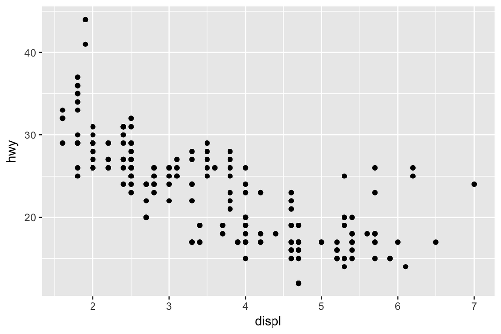

  ```r
  ggplot(data = mpg) +
    geom_point(mapping = aes(x = displ, y = hwy))
  ```

- Check available aesthetics for a geometric object by help:

```r
?geom_point
```

## Color of points

- Color points according to `class`

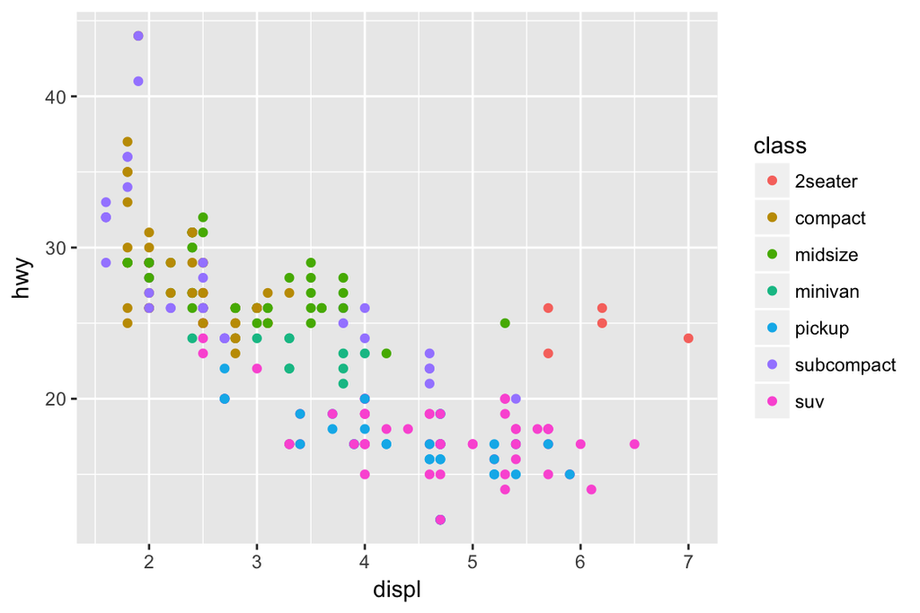

  ```r
  ggplot(data = mpg) +
    geom_point(mapping = aes(x = displ, y = hwy, color = class))
  ```

## Size of points

- Assign different sizes to points according to `class`

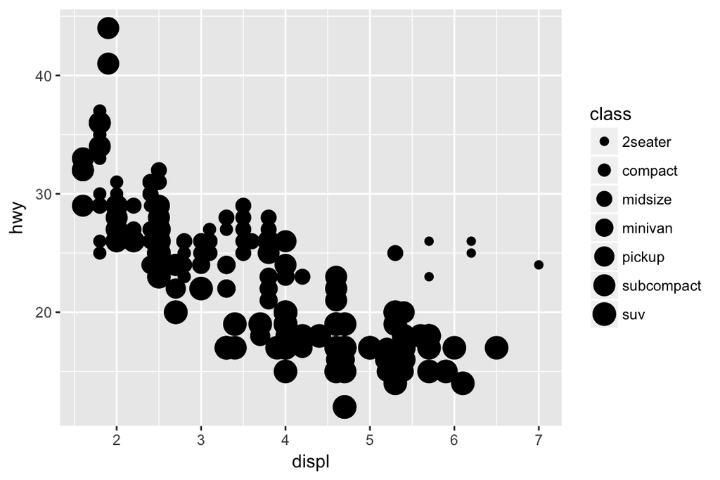

  ```r
  ggplot(data = mpg) +
    geom_point(mapping = aes(x = displ, y = hwy, size = class))
  ```

## Transparency of points

- Assign different transparency levels to points according to `class`

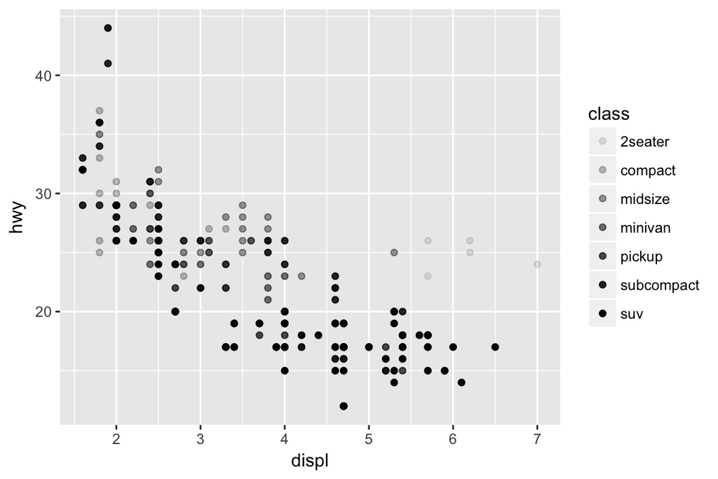

  ```r
  ggplot(data = mpg) +
    geom_point(mapping = aes(x = displ, y = hwy, alpha = class))
  ```

## Shape of points

- Assign different shapes to points according to `class`

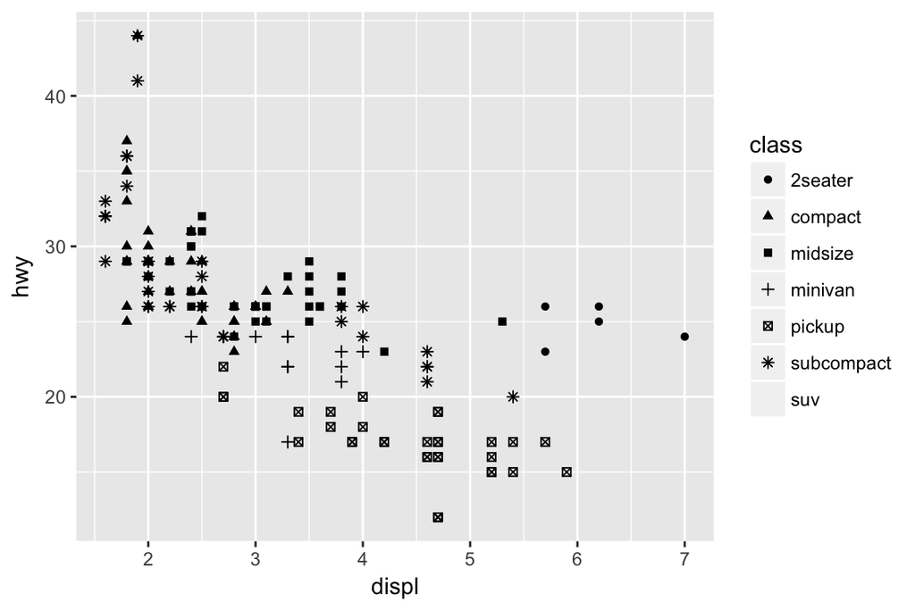

  ```r
  ggplot(data = mpg) +
    geom_point(mapping = aes(x = displ, y = hwy, shape = class))
  ```

## Manual setting of an aesthetic

- Set the color of all points to be blue

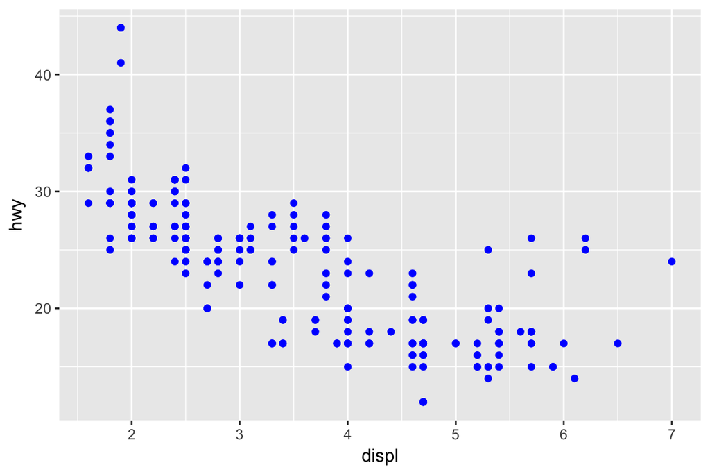

  ```r
  ggplot(data = mpg) +
    geom_point(mapping = aes(x = displ, y = hwy), color = "blue")
  ```

## Facets

## Plotting by groups

- A subplot for each car type:

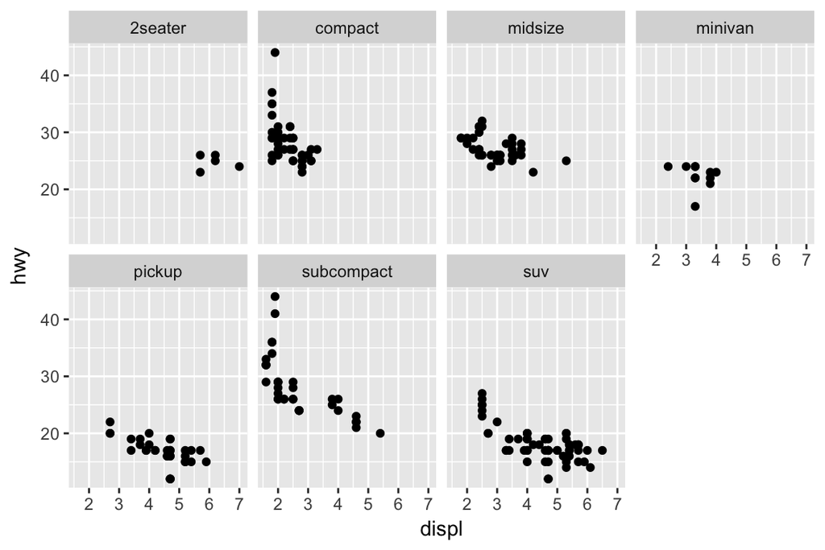

  ```r
  ggplot(data = mpg) +
    geom_point(mapping = aes(x = displ, y = hwy)) +
    facet_wrap(~ class, nrow = 2)
  ```

- A subplot for each car type and drive:

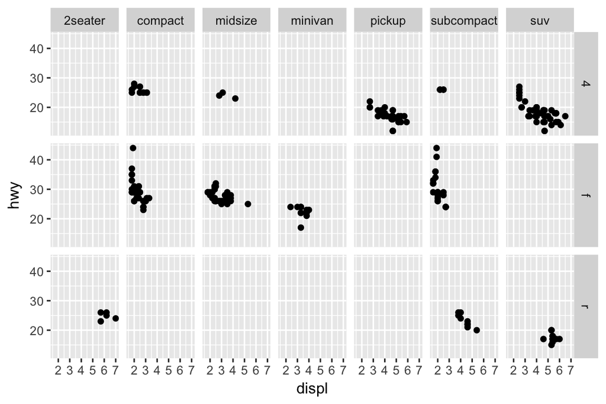

  ```r
  ggplot(data = mpg) +
    geom_point(mapping = aes(x = displ, y = hwy)) +
    facet_grid(drv ~ class)
  ```

## Geometric objects

## Smooth line

- `hwy` vs `displ` line:

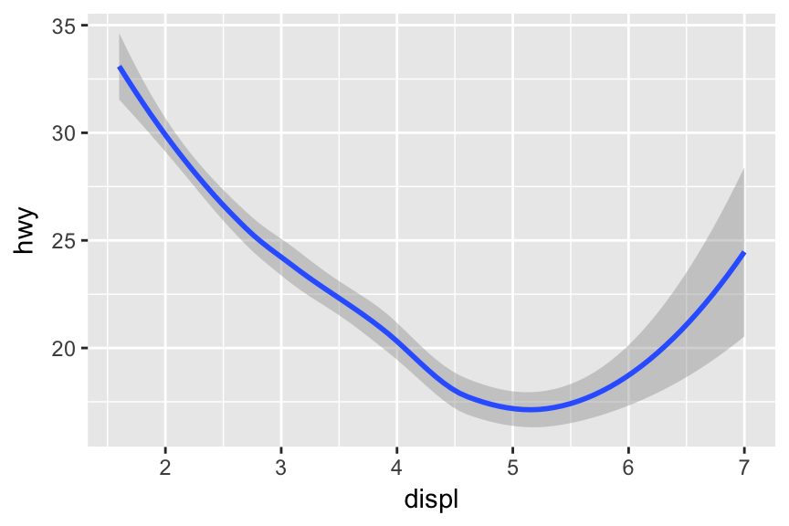

  ```r
  ggplot(data = mpg) +
    geom_smooth(mapping = aes(x = displ, y = hwy))
  ```

## Different line types

- Different line types according to `drv`

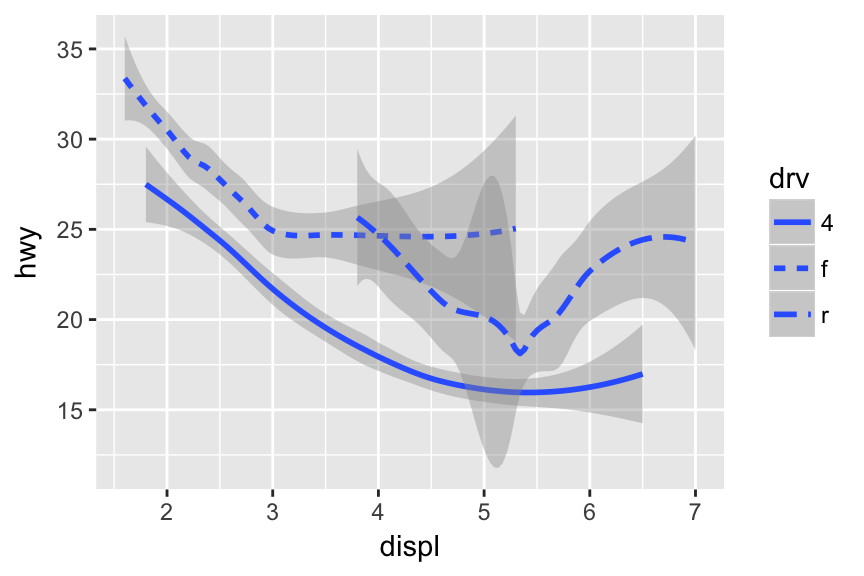

  ```r
  ggplot(data = mpg) +
    geom_smooth(mapping = aes(x = displ, y = hwy, linetype = drv))
  ```

## Different line colors

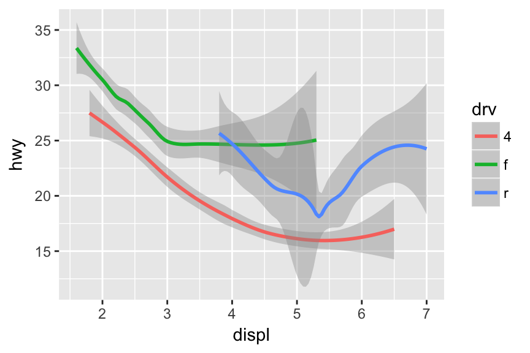

  ```r
  ggplot(data = mpg) +
    geom_smooth(mapping = aes(x = displ, y = hwy, color = drv))
  ```

## Points and lines

- Lines overlaid over scatter plot:

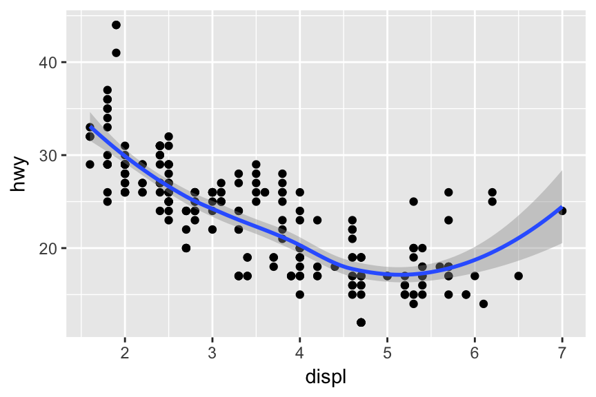

  ```r
  ggplot(data = mpg) +
    geom_point(mapping = aes(x = displ, y = hwy)) +
    geom_smooth(mapping = aes(x = displ, y = hwy))
  ```

- Same as

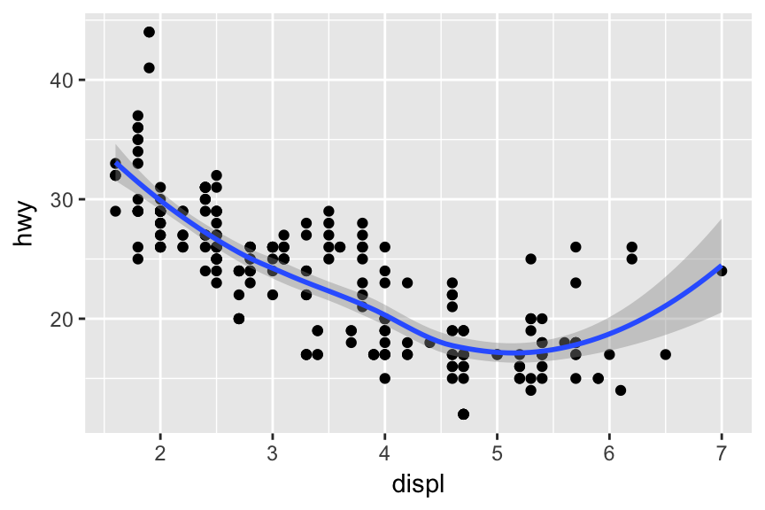

  ```r
  ggplot(data = mpg, mapping = aes(x = displ, y = hwy)) +
    geom_point() + geom_smooth()
  ```

## Aesthetics for each geometric object

- Different aesthetics in different layers:

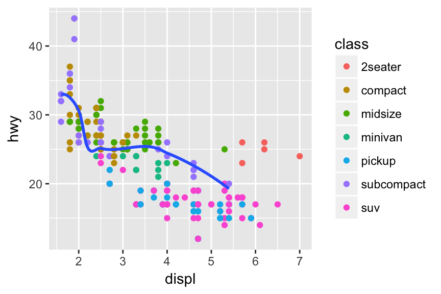

  ```r
  ggplot(data = mpg, mapping = aes(x = displ, y = hwy)) +
    geom_point(mapping = aes(color = class)) +
    geom_smooth(data = filter(mpg, class == "subcompact"), se = FALSE)
  ```

## Bar charts

## `diamonds` data

- `diamonds` data:

  ```r
  diamonds
  ```

  ```
  ## # A tibble: 53,940 x 10
  ##    carat cut       color clarity depth table price     x     y     z
  ##    <dbl> <ord>     <ord> <ord>   <dbl> <dbl> <int> <dbl> <dbl> <dbl>
  ##  1 0.230 Ideal     E     SI2      61.5  55.0   326  3.95  3.98  2.43
  ##  2 0.210 Premium   E     SI1      59.8  61.0   326  3.89  3.84  2.31
  ##  3 0.230 Good      E     VS1      56.9  65.0   327  4.05  4.07  2.31
  ##  4 0.290 Premium   I     VS2      62.4  58.0   334  4.20  4.23  2.63
  ##  5 0.310 Good      J     SI2      63.3  58.0   335  4.34  4.35  2.75
  ##  6 0.240 Very Good J     VVS2     62.8  57.0   336  3.94  3.96  2.48
  ##  7 0.240 Very Good I     VVS1     62.3  57.0   336  3.95  3.98  2.47
  ##  8 0.260 Very Good H     SI1      61.9  55.0   337  4.07  4.11  2.53
  ##  9 0.220 Fair      E     VS2      65.1  61.0   337  3.87  3.78  2.49
  ## 10 0.230 Very Good H     VS1      59.4  61.0   338  4.00  4.05  2.39
  ## # ... with 53,930 more rows
  ```

## Bar chart

- `geom_bar()` creates bar chart:

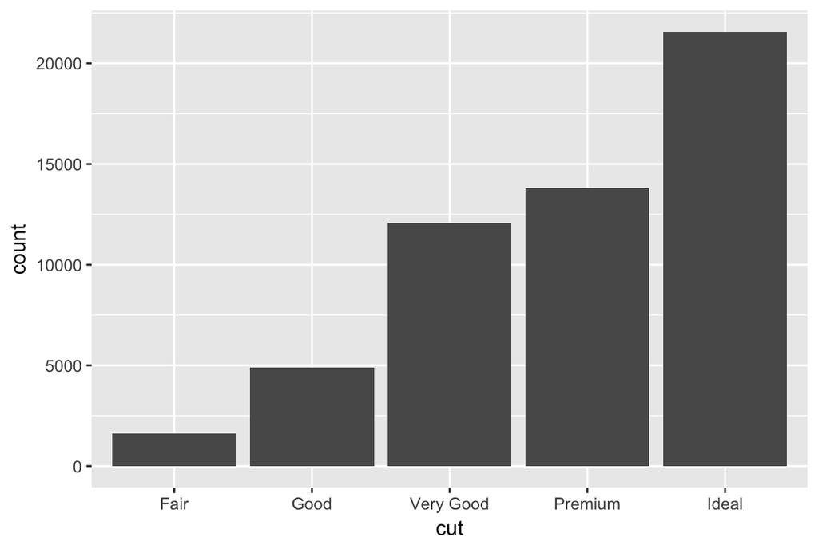

  ```r
  ggplot(data = diamonds) +
    geom_bar(mapping = aes(x = cut))
  ```

- Bar charts, like histograms, frequency polygons, smoothers, and boxplots, plot some computed variables instead of raw data.
- Check available computed variables for a geometric object via help:

  ```r
  ?geom_bar
  ```

- Use `stat_count()` directly:

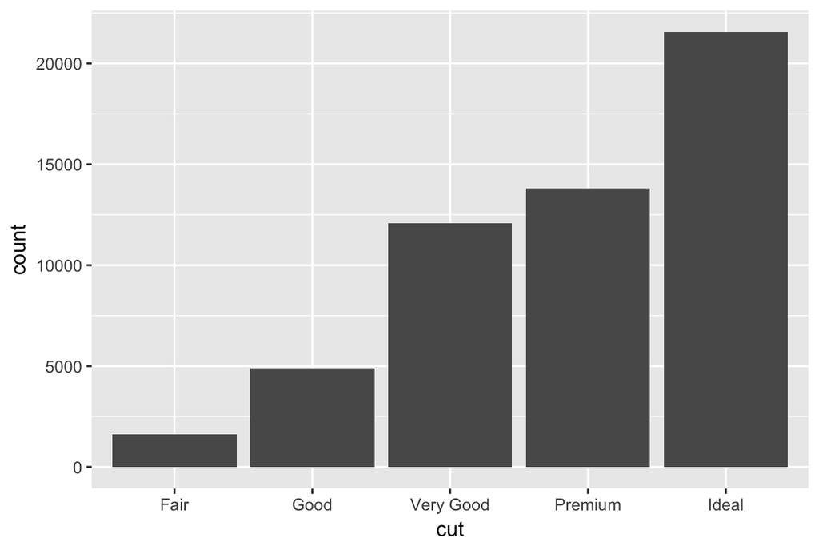

  ```r
  ggplot(data = diamonds) +
    stat_count(mapping = aes(x = cut))
  ```

- `stat_count()` has a default geom `geom_bar()`.
- Display frequency instead of counts:

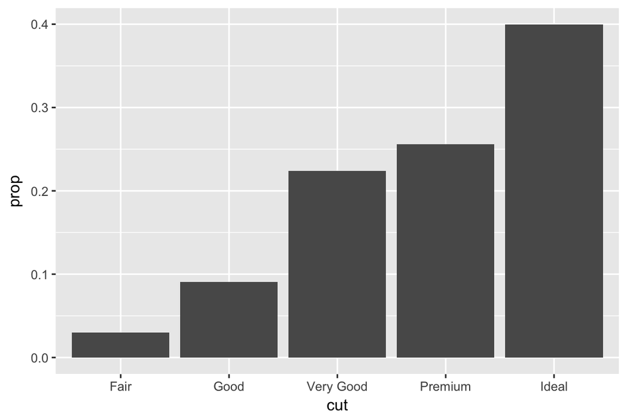

  ```r
  ggplot(data = diamonds) +
    geom_bar(mapping = aes(x = cut, y = ..prop.., group = 1))
  ```

- Color bar:

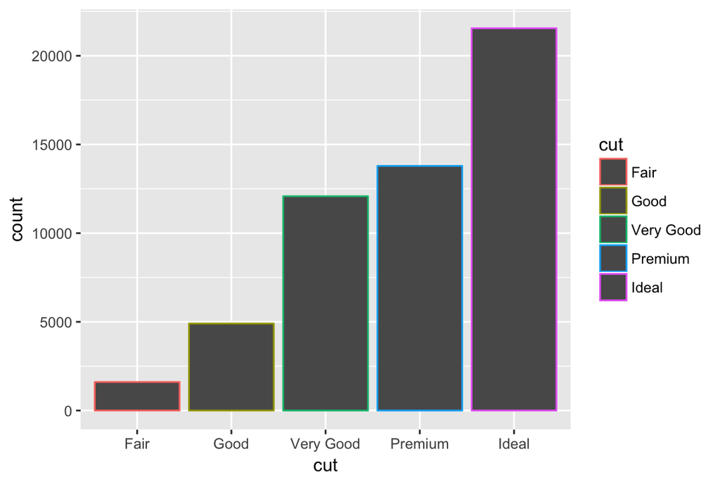

  ```r
  ggplot(data = diamonds) +
    geom_bar(mapping = aes(x = cut, colour = cut))
  ```

- Fill color:

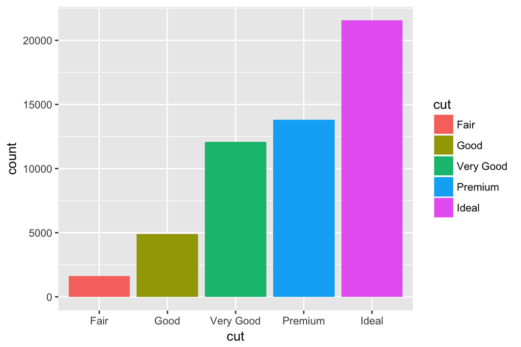

  ```r
  ggplot(data = diamonds) +
    geom_bar(mapping = aes(x = cut, fill = cut))
  ```

- Fill color according to another variable:

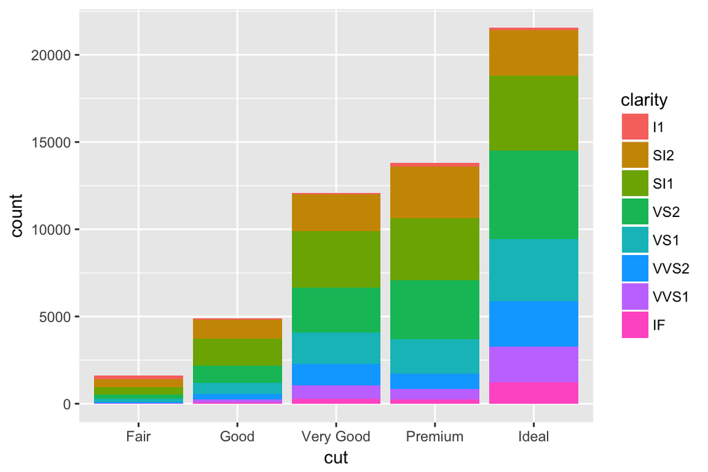

  ```r
  ggplot(data = diamonds) +
    geom_bar(mapping = aes(x = cut, fill = clarity))
  ```

## Positional arguments

- `position_gitter()`:

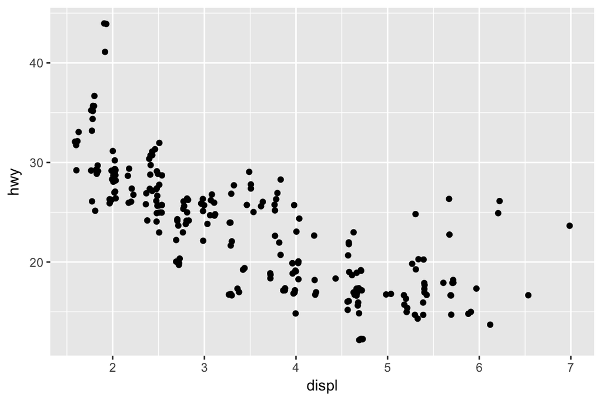

  ```r
  ggplot(data = mpg) +
    geom_point(mapping = aes(x = displ, y = hwy), position = "jitter")
  ```

- `position_fill()`:

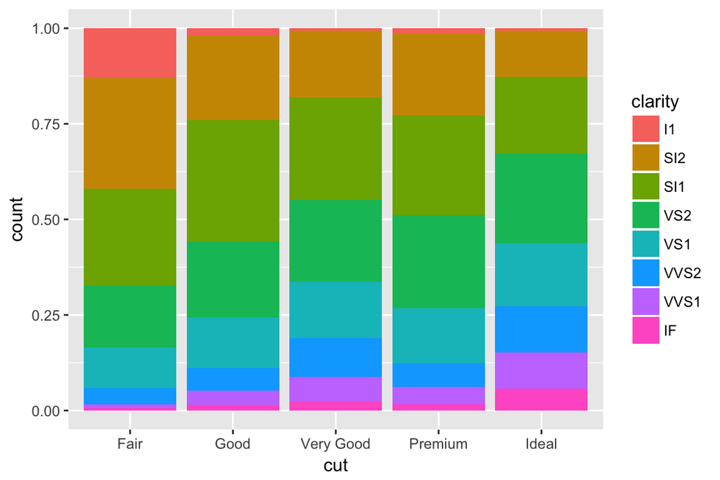

  ```r
  ggplot(data = diamonds) +
    geom_bar(mapping = aes(x = cut, fill = clarity), position = "fill")
  ```

- `position_dodge()`:

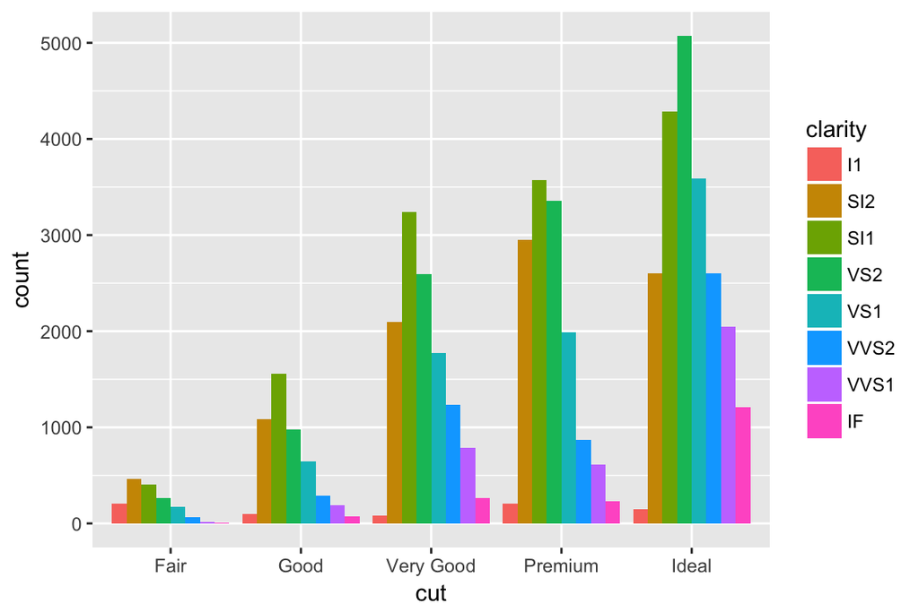

  ```r
  ggplot(data = diamonds) +
    geom_bar(mapping = aes(x = cut, fill = clarity), position = "dodge")
  ```

## Coordinate systems

## `coord_flip()`

- A boxplot:

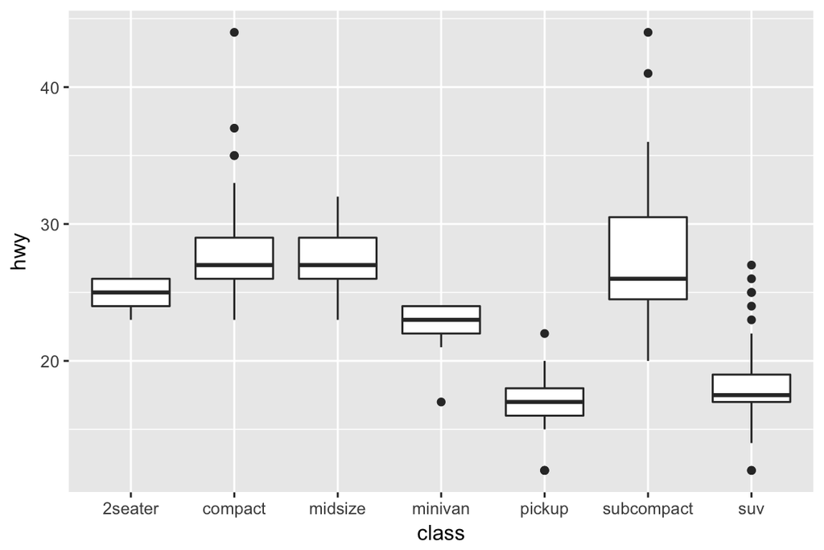

  ```r
  ggplot(data = mpg, mapping = aes(x = class, y = hwy)) +
    geom_boxplot()
  ```

- Flip x- and y- axis:
- A boxplot:

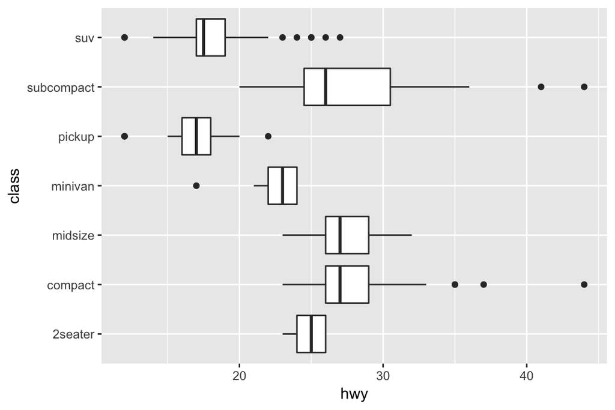

  ```r
  ggplot(data = mpg, mapping = aes(x = class, y = hwy)) +
    geom_boxplot() + coord_flip()
  ```

## `coord_quickmap()`

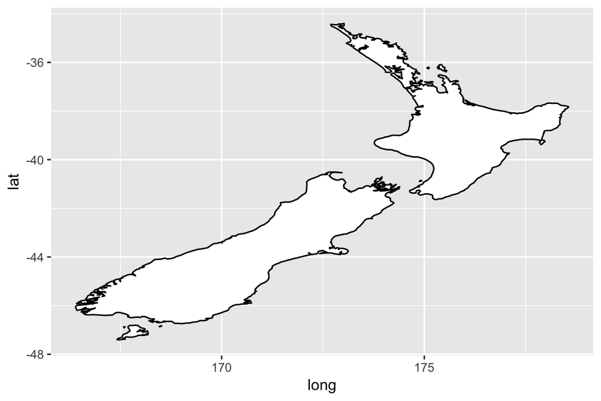

```r
library("maps")
nz <- map_data("nz")

ggplot(nz, aes(long, lat, group = group)) +
  geom_polygon(fill = "white", colour = "black")
```

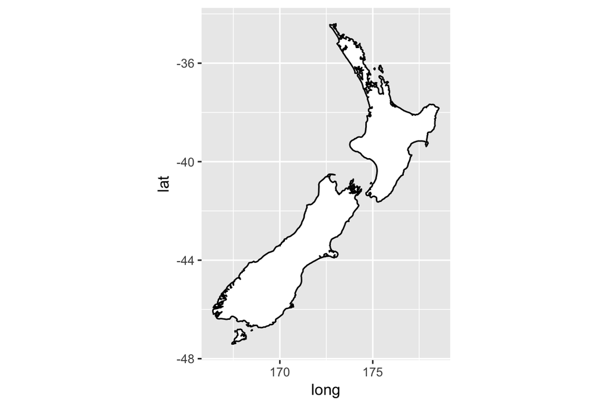

```r
ggplot(nz, aes(long, lat, group = group)) +
  geom_polygon(fill = "white", colour = "black") +
  coord_quickmap()
```